# Clustering of employer expectancies with BayesMallows

Christoph Krausser

1/14/2022

Hypothesizing that we may not need more than 10 clusters to find a useful partitioning of the assessors, we start by doing test runs with 1, 3, 5, and 10 mixture components in order to assess convergence. We set the number of Monte Carlo samples to 5,000, and since this is a test run, we do not save cluster assignments nor within-cluster distances from each MCMC iteration.

```r
#### SETUP ####
require(BayesMallows)
require(parallel)

#### PARAMETERS ####
cores <- 2 # Number of cpu cores for parallel execution
clusters <- c(1, 3, 5, 10) # Clusters for test run
nmc <- 5000 # Monte Carlo samples

cl <- makeCluster(cores)

mat.ranking.bm_test <- compute_mallows_mixtures(n_clusters = clusters,
                                rankings = mat.ranking,
                                nmc = nmc,
                                save_clus = FALSE,
                                include_wcd = FALSE,
                                cl = cl
)

stopCluster(cl)
```

## Convergence diagnostics

The function assess_convergence automatically creates a grid plot when given an object of class BayesMallowsMixtures, so we can check the convergence of a with the command:

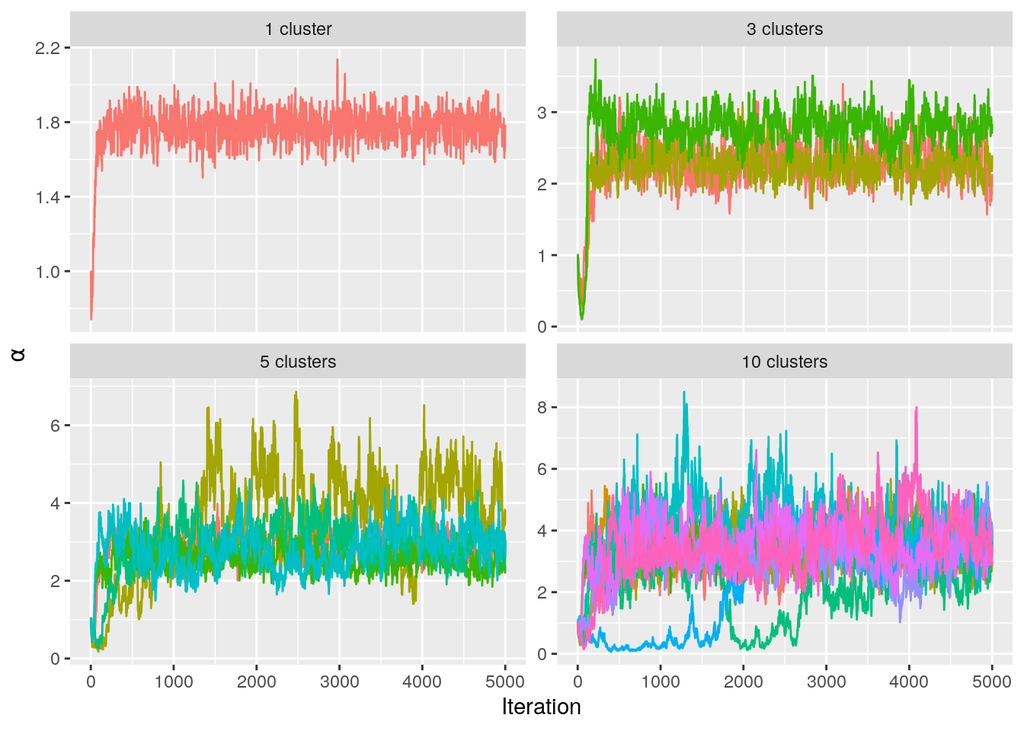

```r
assess_convergence(mat.ranking.bm_test)
```

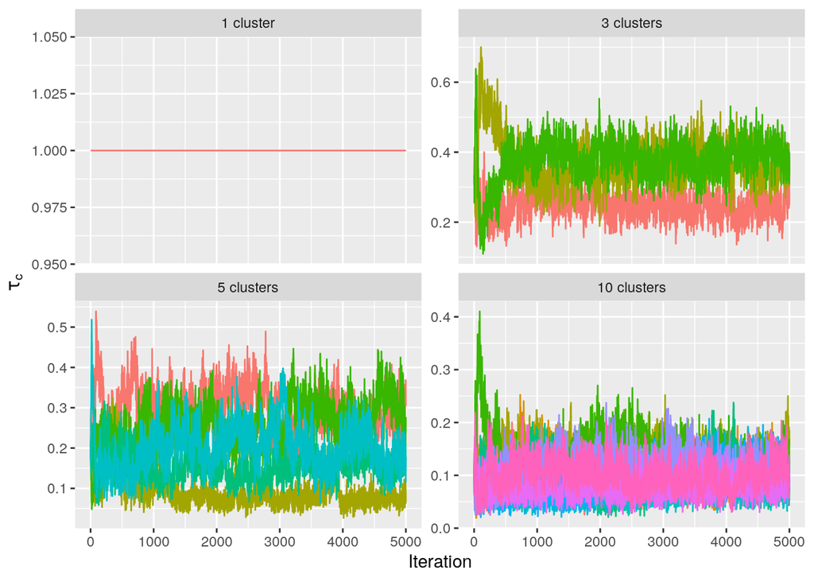

```r
assess_convergence(mat.ranking.bm_test, parameter = "cluster_probs")
```

The plot indicates a good mixing after a few thousand iterations.

## Deciding on the number of mixtures

```r
#### PARAMETERS ####
cores <- 2 # Number of cpu cores for parallel execution
clusters <- 20 # Number of clusters
burn_in <- 5000 # Burn-in
nmc <- 95000 # Monte Carlo samples


cl <- makeCluster(cores)

mat.ranking.bmm <- compute_mallows_mixtures(n_clusters = 1:clusters,
                                rankings = mat.ranking,
                                nmc = (burn_in+nmc),
                                rho_thinning = 10,
                                save_clus = FALSE,
                                include_wcd = TRUE,
                                verbose = TRUE,
                                cl = cl
)

stopCluster(cl)
```

[figure not shown]

```r
plot_elbow(mat.ranking.bmm, burnin = 5000) # Create elbow plot
```

The resulting elbow plot is a notched boxplot, for which upper and lower whiskers represent approximate 95 % confidence intervals. Although not clear-cut, we see that the within-cluster sum of distances levels off at around 3 clusters, and hence we choose to use 3 clusters in our model.

## Posterior distributions

Having chosen 3 mixture components, we go on to fit a final model, still running 95,000 iterations after burnin. This time we call compute_mallows and set n_clusters = 3.

```r
#### PARAMETERS ####
clusters <- 3 # Number of final clusters
burn_in <- 5000 # Burn-in
nmc <- 95000 # Monte Carlo samples e.g. 95000

mat.ranking.bm <- compute_mallows(rankings = mat.ranking,
                          n_clusters = clusters,
                          save_clus = TRUE,
                          clus_thin = 10,
                          nmc = (burn_in+nmc),
                          rho_thinning = 10,
                          verbose = TRUE
)

mat.ranking.bm$burnin <- burn_in # Set bun-in
```

We can plot the posterior distributions of α and ρ in each cluster using plot.BayesMallows:

[figure not shown]

```r
assess_convergence(mat.ranking.bm)
```

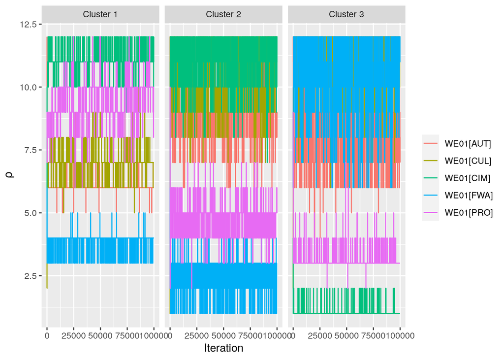

```r
assess_convergence(mat.ranking.bm, parameter = "rho", items = 1:5)
```

We can also show the posterior distributions of the cluster probabilities, using:

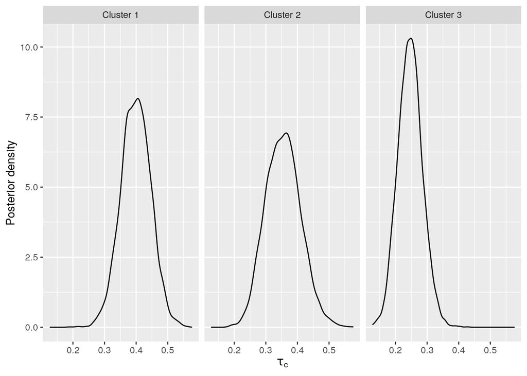

```r
plot(mat.ranking.bm, parameter = "cluster_probs")
```

Using the argument parameter = “cluster_assignment”, we can visualize the posterior probability for each assessor of belonging to each cluster:

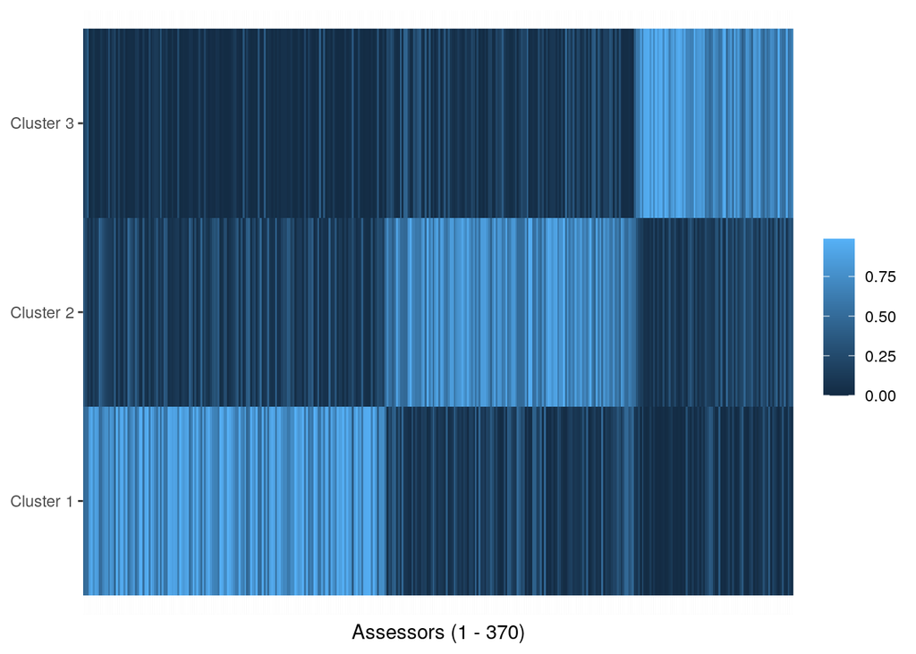

```r
plot(mat.ranking.bm, parameter = "cluster_assignment")
```

The underlying numbers can be obtained using the function assign_cluster.

```r
print(mat.ranking.bm_res[["assignment_prop"]])
```

```
##
## Cluster 1 Cluster 2 Cluster 3
## 0.4270270 0.3513514 0.2216216
```

```r
print.data.frame(head(mat.ranking.bm_res[["consensus"]], 5))
```

```
##                    Cluster 1                  Cluster 2               Cluster 3
## 1          Interesting tasks                High Salary           Company image
## 2     Meaningfulness of work          Interesting tasks             High Salary
## 3           Work environment Flexible work arrangements Prospects for Promotion
## 4 Flexible work arrangements               Job security  Meaningfulness of work
## 5                High Salary    Prospects for Promotion       Interesting tasks
```

```r
mat.ranking.bm_res[["assignments_simple"]]
```

```
## # A tibble: 370 × 3
##    assessor cluster   probability
##       <dbl> <chr>           <dbl>
##  1        1 Cluster 1       0.486
##  2        2 Cluster 1       0.519
##  3        3 Cluster 1       0.508
##  4        4 Cluster 2       0.728
##  5        5 Cluster 1       0.854
##  6        6 Cluster 1       0.932
##  7        7 Cluster 1       0.741
##  8        8 Cluster 2       0.535
##  9        9 Cluster 2       0.526
## 10       10 Cluster 2       0.390
## # … with 360 more rows
```